# AMSS Lecture 8: UML Design – Additional Diagram Types

Traian-Florin Șerbănuță

2025

# Agenda

### Interaction Diagrams

- Communication Diagrams
- Interaction Overview Diagrams
- Timing Diagrams

### Structure Diagrams

- Composite Structure Diagrams

# Interaction Diagrams

# 1. Communication Diagrams

Emphasize data links between participants in the interaction.

- free placement of participants
- draw links to show how participant connect
- use numbering to show message sequence

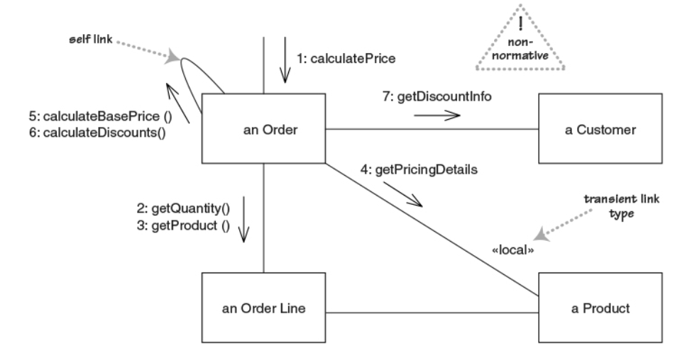

# 1. Communication Diagrams (nested numbering)

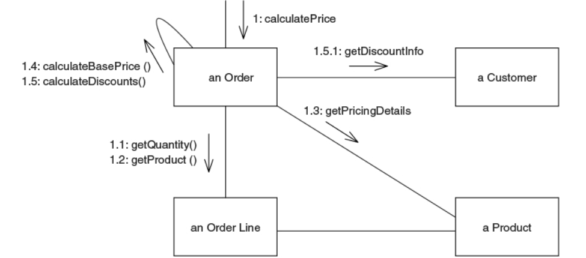

- Can use letters to indicate different threads
  - e.g., 1a1 and 1b1 indicate two threads within message 1
- Nested numbers can get hard to follow (e.g., 1.1.1.2.1.1.)
  - Some people prefer using flat numbers as on previous slide
- Don’t have precise notation for control logic

# 1. Communication Diagrams (example)

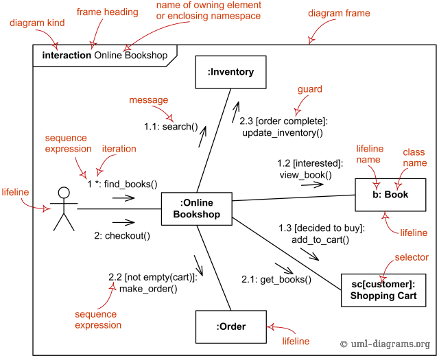

# 1. Communication Diagrams vs. Sequence Diagrams

- **Sequence diagrams** highlight temporal sequencing.
- **Communication diagrams** highlight structural organization

| Aspect | Sequence Diagram | Communication Diagram |
| --- | --- | --- |
| Focus | Flow of messages | Structural relationships among objects |
| Emphasis | *When* messages occur | *Which* objects interact |
| Layout | Vertical lifelines; message flow top-to-bottom | Graph layout; objects linked by message paths |
| Best For | message order, concurrency, timing | Collaboration structure and object roles |
| Mesage Order | Vertical position | Explicit sequence numbers (1, 1.1, 2…) |
| Use Case | Complex logic, workflows, time-dependent behavior | High-level interaction patterns object relationships |

# Interactive Exercise

### Task

Model the basic interactions within an online ordering system when a customer places a food order online.

### Guidelines

- Use at least 4 objects (CustomerApp, OrderService, RestaurantSystem, PaymentService).
- Number your messages.
- model possible failures.

# 2. Interaction Overview Diagrams

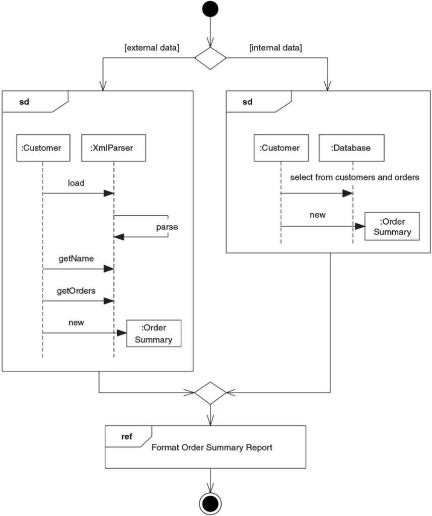

- Activity diagrams where actions are Interaction Diagrams (or references).
- High-level control flow combining multiple interactions.

# 2. Interaction Overview example (all references)

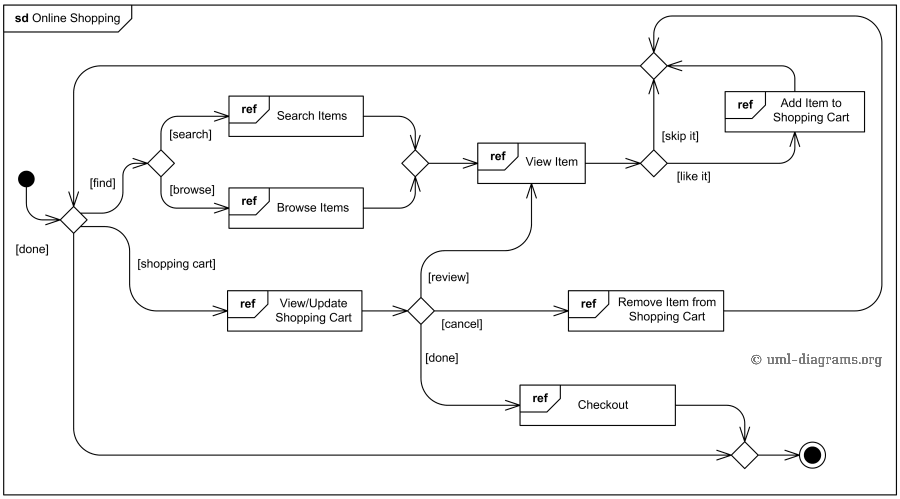

# 2. Interaction Overview example

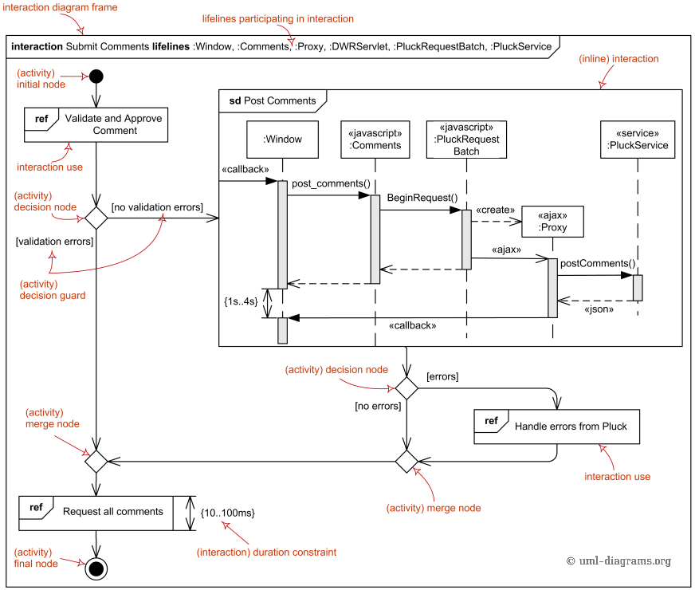

# 2. Interaction Overview exercise (Library Book Borrowing)

### Task

Create an Interaction Overview Diagram (IOD) that shows the control flow of a user borrowing a book through an online library portal.

### Guidelines

The diagram must include at least one interaction sub-diagram, such as a short sequence diagram or communication diagram.

The system consists of:

- UserPortal
- SearchService
- CatalogService
- LoanService
- NotificationService

# 3. Timing Diagrams

Focus: timing constraints between state changes on different objects

- Show the *change of state over time*.
- Hardware design: modelling of real-time / cyberphysical systems

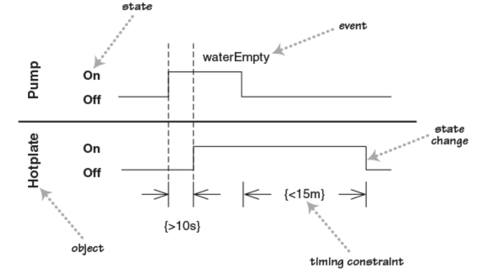

# 3. Timing Diagrams with cross state-changes

- Useful when there are more states

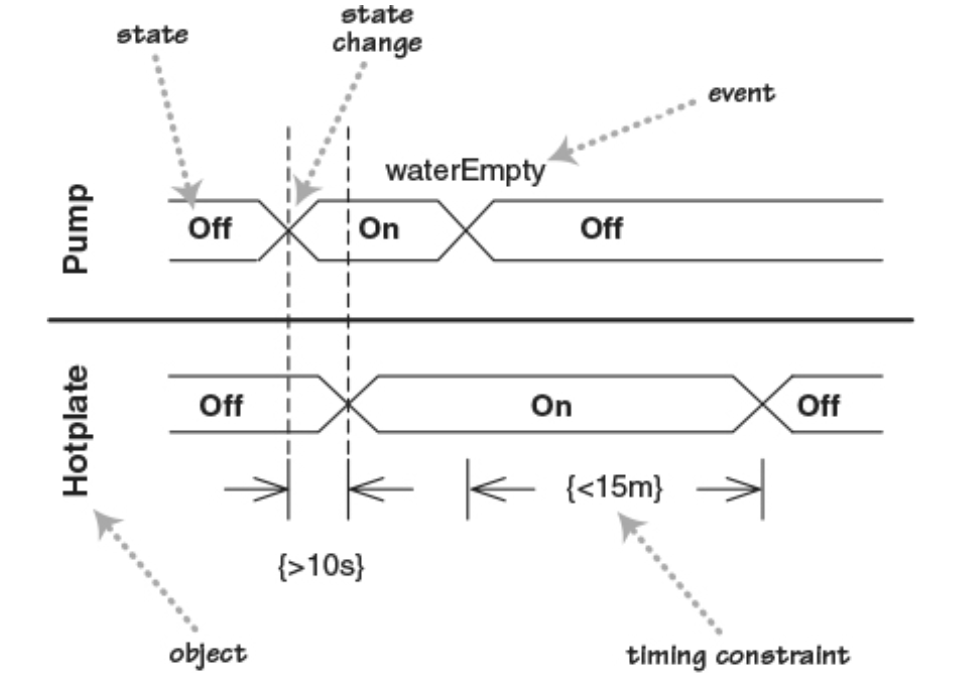

# 3. Timing diagrams example (including messages)

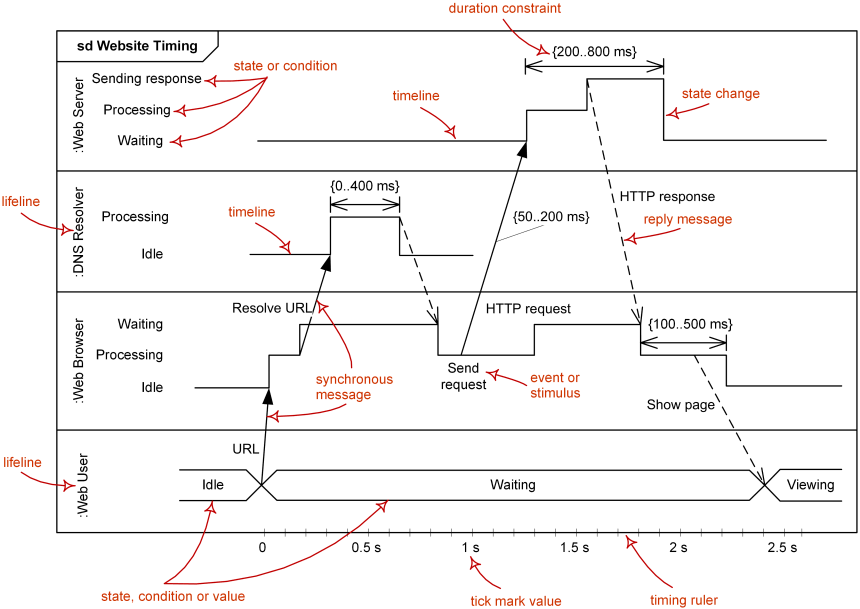

# 3. Timing Diagram exercise

Create a UML Timing Diagram showing how three components in a smart-home lighting system (motion sensor, light controller, light) change states over time and respond to each other.

### Initial States

- MotionSensor = DetectingMotion
- LightController = Active
- Light = ON

### Sequence of Events

1. At t = 0s, the MotionSensor switches to NoMotion.
2. After 10 seconds of no motion, the LightController transitions from Active → WaitingToOff.
3. At t = 12s, the MotionSensor briefly detects motion again (DetectingMotion), causing:

   LightController → Active (cancel auto-off)
4. At t = 18s, MotionSensor returns to NoMotion.
5. After another 10 seconds of continuous no motion (i.e., at t = 28s), LightController sends command Light = OFF

# Structure Diagrams

# 4. Composite Structure Diagrams

Used to show:

- internal structure
  - interactions with environment through ports
- behavior of a collaboration

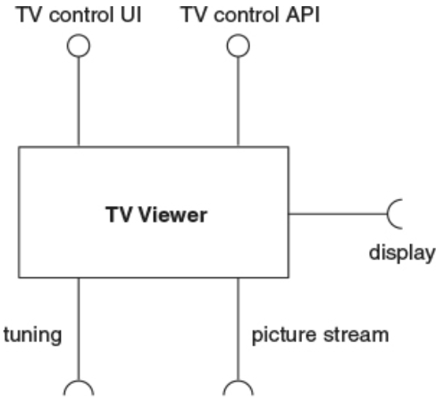

TV Viewer Class

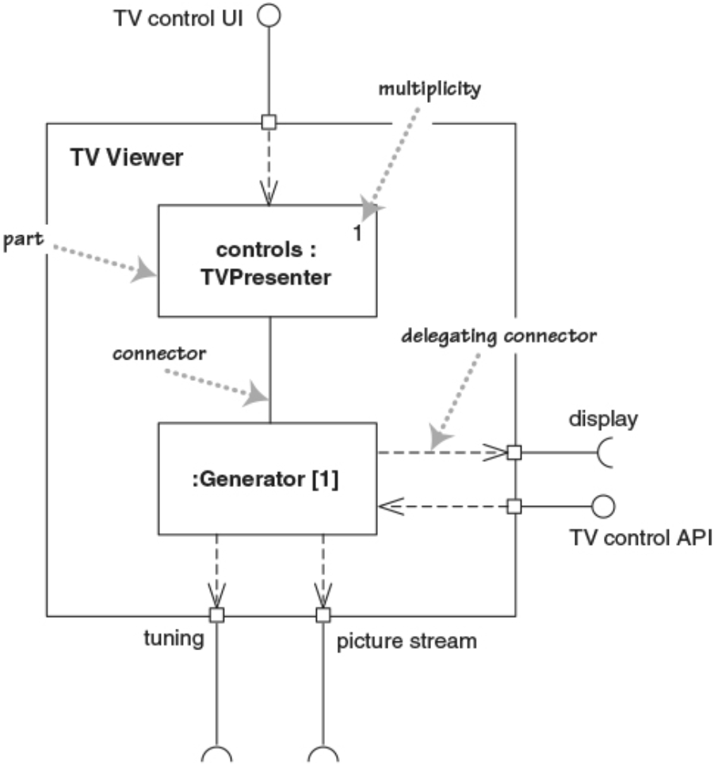

TV Viewer as Composite Structure

# 4. Composite Structures example (internal structure)

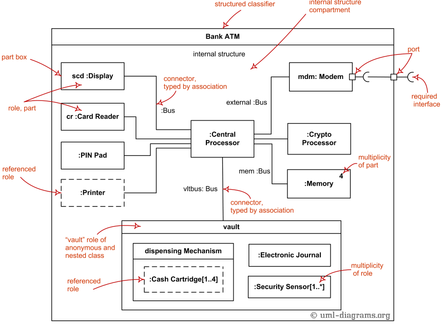

# 4. Composite Structures example (collaboration)

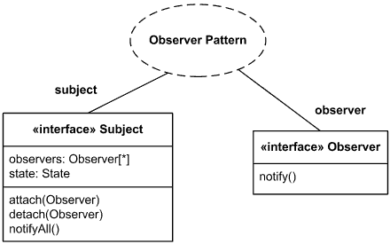

Observer design pattern as a composite structure

- Collaboration icon is connected to each of the rectangles
- Rectangles denote interfaces
  - types of properties of the collaboration.
- Each line is labeled by the name of the property (role).

# 4. Composite Structures exercise

Create a Composite Structure Diagram showing the internal structure of an AudioPlayback component in a music-player app.

### Scenario

You are given a component called AudioPlayback, responsible for decoding and playing audio files. Internally, it contains three parts:

- Decoder
- Buffer
- OutputDevice (e.g., speakers or headphone jack)

AudioPlayback component interacts with environment through:

- controlPort – receives play/pause/stop commands
- audioPort – sends raw audio samples to hardware

### Optional additions

- A visualizer
- A volume control

# Wrap-Up

### Summary Table

| Diagram Type | Purpose |
| --- | --- |
| Communication | Data links and message sequence |
| Interaction Overview | High-level flow |
| Timing | Time-based behavior |
| Composite Structure | Internal architecture |